# Data Science Pipeline Tutorial

# What Makes You Twitch?

Ryan Druffel

UUID: 116044981

In this tutorial, we will be exploring the Data Science Pipeline. This process has several phases where data has to be collected, managed, explored, interpreted and communicated. For this tutorial, I have chosen to analyze some statistics about the [top twitch streamers](https://www.kaggle.com/aayushmishra1512/twitchdata) since my sister has shown an interest in streaming games on twitch. Through this tutorial we will examine the performance of the top 1000 twitch streamers and try and draw some relationships between their varying statistics and their rank. Ideally, by the end of the process, we will be able to make some form of recommendation to my sister on how she should go about streaming by observing the existing data and making preditions about what statistics you need to rank up.

## Project Setup

Before we can take our first steps, it is important to import some packages to help extract and analyze the data. The pandas library will help us extract and organize data; the numpy library is helpful for numerical manipulation; the matplotlib library will allow us to make visualizations of the data; and the sklearn library will help us make regressions to make predictions.

```python
import pandas as pd
import numpy as np
import matplotlib.pyplot as plt
import scipy.optimize
from sklearn.linear_model import LinearRegression
from sklearn.datasets import make_regression
```

## Data Collection

The first step is to get access to the data. While twitch does have an api where you could collect data on specific streamers, we will keep it simple by using a premade data table. By travelling to [this url](https://www.kaggle.com/aayushmishra1512/twitchdata) and downloading the zip file, you can extract the csv file and open it in using the pandas library. By using pandas' `read_csv` function, we can convert the csv file into a data table.

```python
# Read data from csv
data = pd.read_csv("twitchdata.csv")

# Display data table head
data
```

|  | Channel | Watch time(Minutes) | Stream time(minutes) | Peak viewers | Average viewers | Followers | Followers gained | Views gained | Partnered | Mature | Language |
| --- | --- | --- | --- | --- | --- | --- | --- | --- | --- | --- | --- |
| 0 | xQcOW | 6196161750 | 215250 | 222720 | 27716 | 3246298 | 1734810 | 93036735 | True | False | English |
| 1 | summit1g | 6091677300 | 211845 | 310998 | 25610 | 5310163 | 1370184 | 89705964 | True | False | English |
| 2 | Gaules | 5644590915 | 515280 | 387315 | 10976 | 1767635 | 1023779 | 102611607 | True | True | Portuguese |
| 3 | ESL_CSGO | 3970318140 | 517740 | 300575 | 7714 | 3944850 | 703986 | 106546942 | True | False | English |
| 4 | Tfue | 3671000070 | 123660 | 285644 | 29602 | 8938903 | 2068424 | 78998587 | True | False | English |
| ... | ... | ... | ... | ... | ... | ... | ... | ... | ... | ... | ... |
| 995 | LITkillah | 122524635 | 13560 | 21359 | 9104 | 601927 | 562691 | 2162107 | True | False | Spanish |
| 996 | 빅헤드 (bighead033) | 122523705 | 153000 | 3940 | 793 | 213212 | 52289 | 4399897 | True | False | Korean |
| 997 | 마스카 (newmasca) | 122452320 | 217410 | 6431 | 567 | 109068 | -4942 | 3417970 | True | False | Korean |
| 998 | AndyMilonakis | 122311065 | 104745 | 10543 | 1153 | 547446 | 109111 | 3926918 | True | False | English |
| 999 | Remx | 122192850 | 99180 | 13788 | 1205 | 178553 | 59432 | 2049420 | True | False | French |

1000 rows × 11 columns

## Data Manipulation

Now that we have the data loaded, we will want to make a few changes to improve the data at hand. Improvements to data can come in multiple forms including the handling of missing or faulty data as well as the creation of new columns with reorganized data.

### Cleaning Missing or Faulty Data

The first thing we might want to do is clean our data. Often when you find data online, some of the data may be missing for various reasons. Some data may be expunged to protect user privacy, some values may be null due to instumentation issues, or some data may be missing intentionally as it is not applicable. Regardless of the reason behind this missing data, it still has to be addressed.

When deciding what to do with missing data, it is important to figure out why the data is missing. If the data is truly missing completely at random (MCAR), then its absence should not affect overall trends in the data. If the data is missing at random (MAR), a somewhat confusing designation, then that means there is a trend in the missing data itself meaning it can be estimated using other data in the table. If data is not missing at random then you will need to factor that into your later analyses. For example, if all data in a column for a specific gender was missing, then you would need to factor that into your final conclusion and any observations made.

In order to skim our data table for missing data, lets check for any missing or corrupted data. Specifically we will want to look for values in the table that are not expected.

```python
# Define functions to search for missing or faulty
def get_string_column_errors(data, col_name):
    # Ensure strings are not missing or empty
    return data.loc[(data[col_name] == "") | (data[col_name] == None)]
def get_bool_column_errors(data, col_name):
    # Ensure booleans are true or false
    return data.loc[(data[col_name] != True) & (data[col_name] != False)]
def get_int_column_errors(data, col_name):
    # Ensure that numbers are not missing
    return data.loc[(data[col_name] == np.nan) | (data[col_name] == None)]

# List each column to be checked with its corresponding "get error" function
columns = [
    ["Channel", get_string_column_errors],
    ["Watch time(Minutes)", get_int_column_errors],
    ["Stream time(minutes)", get_int_column_errors],
    ["Peak viewers", get_int_column_errors],
    ["Average viewers", get_int_column_errors],
    ["Followers", get_int_column_errors],
    ["Followers gained", get_int_column_errors],
    ["Views gained", get_int_column_errors],
    ["Partnered", get_bool_column_errors],
    ["Mature", get_bool_column_errors],
    ["Language", get_string_column_errors]
]

# Check each column
print("Amount of Data Missing by Column")
for column in columns:
    print(column[0] + ": " + str(len(column[1](data, column[0]))))
```

```
Amount of Data Missing by Column
Channel: 0
Watch time(Minutes): 0
Stream time(minutes): 0
Peak viewers: 0
Average viewers: 0
Followers: 0
Followers gained: 0
Views gained: 0
Partnered: 0
Mature: 0
Language: 0
```

Luckily for us, we can see that the program or person who compiled this list was able to completely fill the table; none of the data is faulty or missing.

### Reformatting Existing Data

In addition to handling missing or corrupted data, we may want to further manipulate the existing data. Observing our various dimensions, we can see that some of them are intertangled. When relating Twitch channels to each other using certain columns, there are extra factors at play which can effect the outcome. In order to better isolate certain variables, we can create new columns of data. For example, `Watch time` is affected both by the amount of time a streamer streams (`Stream time`) as well as the number of viewers they have (`Average viewers`). In order to isolate some of this data or remove certain variables, we can divide columns like `Watch time` can be divided by `Stream time`, `Average viewers` or both to estimate things like the amount of time each minute of their content is watched by viewers.

With this technique in mind, we are going to append a few new columns to our data table using the information we already have.

- `Stream consumption` <= `Watch time` / `Stream time`
- `Follower watch rate` <= `Average viewers` / `Followers`
- `Follow percentage` <= `Followers gained` / `Views gained`

We will also create one other new column to show the top streamer's rank to make plotting by it easier in the future.

```python
# Define function to add new columns
def add_column(data, col_name, calc_value):
    data[col_name] = [None] * len(data)
    for index, row in data.iterrows():
        data.at[index, col_name] = calc_value(row, index)

# Add new columns
add_column(data, 'Stream consumption', lambda x, y: x['Watch time(Minutes)'] / x['Stream time(minutes)'])
add_column(data, 'Follower watch rate', lambda x, y: x['Average viewers'] / x['Followers'])
add_column(data, 'Follow percentage', lambda x, y: x['Followers gained'] / x['Views gained'])
add_column(data, 'Rank', lambda x, y: y + 1)

# Show extra columns
data.head()
```

|  | Channel | Watch time(Minutes) | Stream time(minutes) | Peak viewers | Average viewers | Followers | Followers gained | Views gained | Partnered | Mature | Language | Stream consumption | Follower watch rate | Follow percentage | Rank |
| --- | --- | --- | --- | --- | --- | --- | --- | --- | --- | --- | --- | --- | --- | --- | --- |
| 0 | xQcOW | 6196161750 | 215250 | 222720 | 27716 | 3246298 | 1734810 | 93036735 | True | False | English | 28785.885017 | 0.008538 | 0.018647 | 1 |
| 1 | summit1g | 6091677300 | 211845 | 310998 | 25610 | 5310163 | 1370184 | 89705964 | True | False | English | 28755.350846 | 0.004823 | 0.015274 | 2 |
| 2 | Gaules | 5644590915 | 515280 | 387315 | 10976 | 1767635 | 1023779 | 102611607 | True | True | Portuguese | 10954.41491 | 0.006209 | 0.009977 | 3 |
| 3 | ESL_CSGO | 3970318140 | 517740 | 300575 | 7714 | 3944850 | 703986 | 106546942 | True | False | English | 7668.555916 | 0.001955 | 0.006607 | 4 |
| 4 | Tfue | 3671000070 | 123660 | 285644 | 29602 | 8938903 | 2068424 | 78998587 | True | False | English | 29686.237021 | 0.003312 | 0.026183 | 5 |

## Data Exploration

### Initial Observations

Now that all the data is in order, lets compare the stats of the various top streamers to get some initial insight into their performance. The first the we will do is compare how a streamer's rank compares to their `Average viewers`, `Watch time` and `Stream time`.

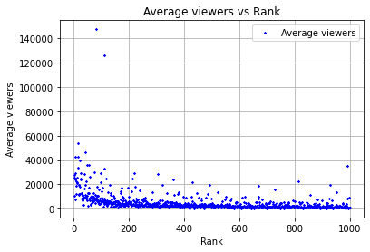

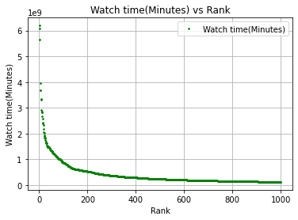

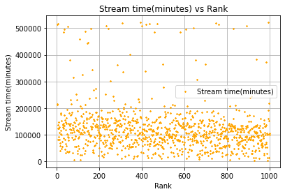

```python
# Define helper classes for styling graphs
class Line:
    def __init__(self, size, style):
        self.size = size
        self.style = style
class Marker:
    def __init__(self, size, mark):
        self.size = size
        self.mark = mark

default_mark = Marker(2, "*")
default_line = Line(2, "solid")

# Define simple graph functions to help reduce reused code
def new_graph(title, x_label="", y_label=""):
    plt.close("all") # Start a new graph
    plt.title(title) # Set graph title
    plt.xlabel(x_label) # Set x axis label
    plt.ylabel(y_label) # Set y axis label
def add_to_graph(data, x_col, y_col, color='blue', line=Line(0, ""), marker=Marker(0, "")):
    plt.plot(
        x_col, y_col, data=data,
        markersize=marker.size if marker.size != None else 0,
        marker=marker.mark if marker.mark != None else '',
        color=color,
        linewidth=line.size if line.size != None else 0,
        linestyle=line.style if line.style != None else ''
    )
def finish_graph():
    plt.legend()
    plt.grid()
    plt.show()
def graph_alone(data, x_col, y_col, color='blue', line=Line(0, ""), marker=Marker(0, "")):
    new_graph(y_col + " vs " + x_col, x_col, y_col)
    add_to_graph(data, x_col, y_col, color=color, line=line, marker=marker)
    finish_graph()

# Graph the aformentioned relations
graph_alone(data, 'Rank', 'Average viewers', 'blue', marker=default_mark)
graph_alone(data, 'Rank', 'Watch time(Minutes)', 'green', marker=default_mark)
graph_alone(data, 'Rank', 'Stream time(minutes)', 'orange', marker=default_mark)
```

From these graphs, we can make a couple observations. In the first graph, average viewers vs rank, there seems to be some correlation between the average viewers and rank; however, there are many outliers in this trend implying that there may be other factors that affect this relationship.

From the watch time vs rank graph, we can see a that rank is directly correlated to the amount of watch time a channel has. This is actually how the top streamers were chosen in this case so this is what we would expect to see. One other thing to note about watch time with respect to rank is that the relationship seems to be exponential. We can further explore this trend by graphing the relationship on a logarithmic scale. Since we see a somewhat similar behavior in the first graph, we may see a more identifiable trend by graphing that on a logarithmic scale as well.

When it comes to stream time, there does not seem to be any discernable relationship between it and rank to the naked eye.

### Trying Another Angle

As humans, it is important to know our limits. We may be masters at recognizing patterns but it isn't always easy to see them when the format is wrong. By reformatting the graphs on a logarithmic scale, we may find that the patterns (relationships) are easier to see.

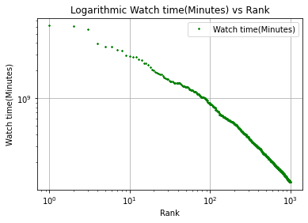

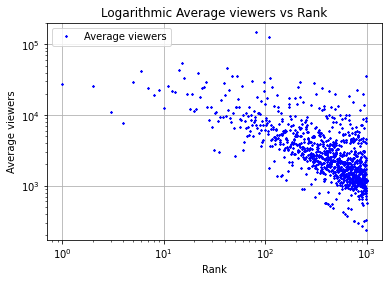

```python
# Define logarithmic graph function to reduce code reuse
def make_graph_log():
    plt.xscale("log")
    plt.yscale("log")
def graph_alone_log(data, x_col, y_col, color='blue', line=Line(0, ""), marker=Marker(0, ""), title=None):
    new_graph("Logarithmic " + y_col + " vs " + x_col if title == None else title, x_col, y_col)
    add_to_graph(data, x_col, y_col, color=color, line=line, marker=marker)
    make_graph_log()
    finish_graph()

# Graph Watch time vs Rank on a Logarithmic scale
graph_alone_log(data, 'Rank', 'Watch time(Minutes)', 'green', marker=default_mark)

# Graph Average viewers vs Rank on a Logarithmic scale
graph_alone_log(data, 'Rank', 'Average viewers', 'blue', marker=default_mark)
```

In both of these new graphs, the relationship between the two values becomes clearer. The relationship for watch time and rank is nearly linear on this transform. Despite the noise on the average viewers vs rank graph, the data is generally clustered around a single regression.

With this information, we can begin to form a hypothesis. From the above graphs we can hypothesize that both watch time and average viewers have an exponential relationship; however, rank and watch time depend on more factors than simply average viewers as the anticipated regressions should look rather different. If you aren't aware of what a regression is, they are also referred to a lines (or curves) of best fit; they are theoretical functions that predict the behavior of a relationship.

### Looking Deeper

Before we test our initial hypothesis, lets look at some other statistics and see if we can find any correlations to better develop our hypothesis. During our data manipulation phase, we made a couple extra columns for our data table. Lets go ahead and see if they give us any more insight on what influences twitch channels' watch time. We can also try separating mature channels and partnered channels for the existing relationships to see if that shows any new patterns.

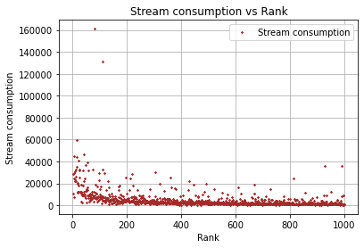

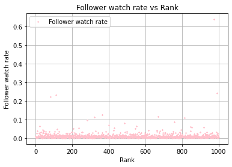

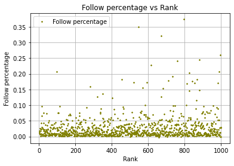

```python
# Graph some alternative columns
graph_alone(data, 'Rank', 'Stream consumption', 'brown', marker=default_mark)
graph_alone(data, 'Rank', 'Follower watch rate', 'pink', marker=default_mark)
graph_alone(data, 'Rank', 'Follow percentage', 'olive', marker=default_mark)
```

From these alternative columns, the only one that seems to have any correlation to rank is the stream consumption; however, we know that stream consumption is calculated based on both the watch time and stream time. Theoretically, the values for stream consumption should be spread similarly to average viewers. To make sure that this is the case, lets graph it on a logarithmic scale and compare it to the spread of average viewers.

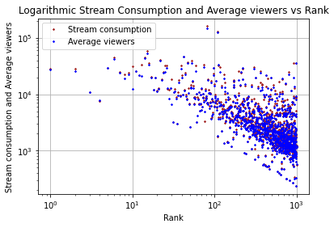

```python
# Graph Average viewers vs Rank on a Logarithmic scale
new_graph("Logarithmic Stream Consumption and Average viewers vs Rank", "Rank", "Stream consumption and Average viewers")
add_to_graph(data, 'Rank', 'Stream consumption', 'brown', marker=default_mark)
add_to_graph(data, 'Rank', 'Average viewers', 'blue', marker=default_mark)
make_graph_log()
finish_graph()
```

These two datasets are very similar to the point where we gain no new information based on this. It is expected that both stream consumption and average viewers be nearly identical and this is the outcome so there is no change to our hypothesis.

Now, lets separate out average viewers by mature and partnership status to see if they have any affect on the output. We are also going to go ahead and plot them on logarithmic graphs as well since we know that the average viewers and rank relationship is easier to see in that format.

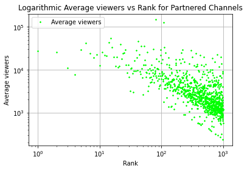

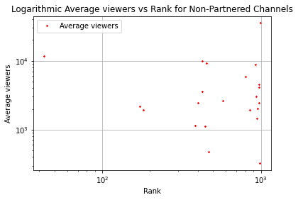

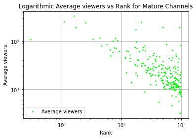

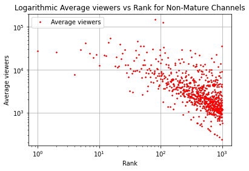

```python
# Separate mature and partnered channels
partnered_channels = data.loc[data["Partnered"] == True]
nonpartnered_channels = data.loc[data["Partnered"] == False]
mature_channels = data.loc[data["Mature"] == True]
nonmature_channels = data.loc[data["Mature"] == False]

# Graph the logarithmic
graph_alone_log(partnered_channels, 'Rank', 'Average viewers', 'lime', marker=default_mark,
                title="Logarithmic Average viewers vs Rank for Partnered Channels")
graph_alone_log(nonpartnered_channels, 'Rank', 'Average viewers', 'red', marker=default_mark,
                title="Logarithmic Average viewers vs Rank for Non-Partnered Channels")
graph_alone_log(mature_channels, 'Rank', 'Average viewers', 'lime', marker=default_mark,
                title="Logarithmic Average viewers vs Rank for Mature Channels")
graph_alone_log(nonmature_channels, 'Rank', 'Average viewers', 'red', marker=default_mark,
                title="Logarithmic Average viewers vs Rank for Non-Mature Channels")
```

Unfortunately, there are few data points for non-partnered channels making it hard to differentiate its trend from partnered channels. The mature channels, on the other hand, show a potentially different trend than the non-mature channels. To further investigate this, lets plot the two on the same graph.

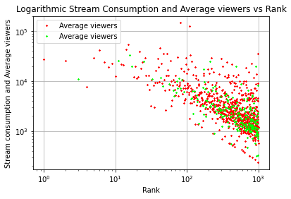

```python
small_mark = Marker(1, '*')

# Plot both mature and non-mature average viewers on the same graph
new_graph("Logarithmic Stream Consumption and Average viewers vs Rank", "Rank", "Stream consumption and Average viewers")
add_to_graph(nonmature_channels, 'Rank', 'Average viewers', 'red', marker=default_mark)
add_to_graph(mature_channels, 'Rank', 'Average viewers', 'lime', marker=default_mark)
make_graph_log()
finish_graph()
```

Eyeballing it, it is hard to tell whether there is any difference in regression for mature vs non-mature channels and their average viewers. Since we have an inkling that this may have an affect on watch time, we will keep this possibility in mind when we begin the next step.

## Hypothesis Testing and Machine Learning

Now that we have developed our general hypothesis, its time to put it to the test. We will be using the scipy package to develop [regressions](https://en.wikipedia.org/wiki/Regression_analysis) for the existing data to see if our hypothesis fits the data numerically. We will be testing both logarithmic and exponential regressions to see how the data behaves.

### Picking a Starting Regression

To start the process, I've picked regressions that behave similar to the trend we are seeing in the average viewers. These starting regressions are not accurate or chosen based on the data we are using, they were simply eyeballed.

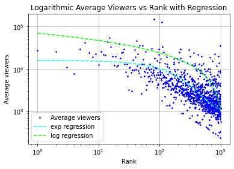

```python
# Define regression functions
def expReg(x, m, t, b, e):
    return m * (e ** (-t * x)) + b
def logReg(x, m, t, b):
    return m * np.log(t * x) + b

# Choose initial values
initial_values_exp = [15000, 0.005, 1000, 2.718]
initial_values_log = [-10000, 0.001, 1000]

# Plot initial regression guesses
m, t, b, e = initial_values_exp
y_vals_exp = [expReg(row["Rank"], m, t, b, e) for index, row in data.iterrows()]
m, t, b = initial_values_log
y_vals_log = [logReg(row["Rank"], m, t, b) for index, row in data.iterrows()]
new_graph("Logarithmic Average Viewers vs Rank with Regression", "Rank", "Average viewers")
add_to_graph(data, 'Rank', 'Average viewers', 'blue', marker=default_mark)
plt.plot(data["Rank"], y_vals_exp, '--', label="exp regression", color="cyan")
plt.plot(data["Rank"], y_vals_log, '--', label="log regression", color="lime")
make_graph_log()
finish_graph()
```

### Refining Regressions

It is clear that these regressions do not properly predict the nature of average viewers and rank; however, from this starting point we can refine the regressions to better match the data. The way in which we are going to do this involves the observation of residuals. A residual is the error in a regression's prediction against the dataset, and by summing up all the residuals of a regression we develop what is called a loss function. If we minimize the output of this loss function, then we can find an ideal regression for the dataset (read more about residuals and how they are used to refine regressions [here](https://www.khanacademy.org/math/statistics-probability/describing-relationships-quantitative-data/regression-library/a/introduction-to-residuals)). Thankfully, scipy does all of this work for us.

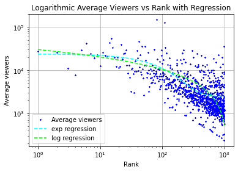

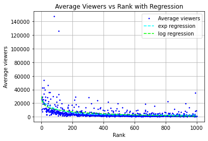

```
Exponential Regression Coefficients: [2.13053211e+04 7.26817053e-03 2.47798535e+03 3.54950452e+00]
Logarithmic Regression Coefficients: [-4.27524436e+03  5.61172659e-04 -1.94542196e+03]
```

```python
# Suppress certain warnings about calculation overflow
import warnings
warnings.filterwarnings("ignore")

# Improve regression
xs = [row["Rank"] for index, row in data.iterrows()]
ys = [row["Average viewers"] for index, row in data.iterrows()]
new_regression_exp, cv_exp = scipy.optimize.curve_fit(expReg, xs, ys, initial_values_exp)
new_regression_log, cv_log = scipy.optimize.curve_fit(logReg, xs, ys, initial_values_log)
m, t, b, e = new_regression_exp
y_vals_exp = [expReg(row["Rank"], m, t, b, e) for index, row in data.iterrows()]
m, t, b = new_regression_log
y_vals_log = [logReg(row["Rank"], m, t, b) for index, row in data.iterrows()]

# Graph new regression in logarithmic scale
new_graph("Logarithmic Average Viewers vs Rank with Regression", "Rank", "Average viewers")
add_to_graph(data, 'Rank', 'Average viewers', 'blue', marker=default_mark)
plt.plot(data["Rank"], y_vals_exp, '--', label="exp regression", color="cyan")
plt.plot(data["Rank"], y_vals_log, '--', label="log regression", color="lime")
make_graph_log()
finish_graph()

# Graph new regression in normal scale
new_graph("Average Viewers vs Rank with Regression", "Rank", "Average viewers")
add_to_graph(data, 'Rank', 'Average viewers', 'blue', marker=default_mark)
plt.plot(data["Rank"], y_vals_exp, '--', label="exp regression", color="cyan")
plt.plot(data["Rank"], y_vals_log, '--', label="log regression", color="lime")
finish_graph()

# Print the regression coefficients
print("Exponential Regression Coefficients: " + str(new_regression_exp))
print("Logarithmic Regression Coefficients: " + str(new_regression_log))
```

### Factoring in Other Variables

During our exploration, we had a consideration for our hypothesis that we have yet to factor in. When splitting data into mature and non-mature channels, we thought there might a some correlation between mature status and rank. Now that we have got into the process of developing regressions for single relationships, we can step up our game to factor in multiple variables into our regressions.

In this next block of code we will put multiple variables into `scipy`'s `curve_fit` function. First we will need to establish our regression function, then organize our input data to put into the `curve_fit` function.

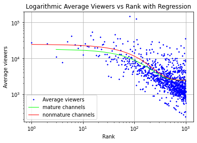

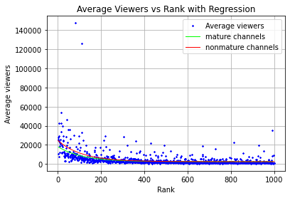

```python
# Define multivar regression function
def expRegMult(X, m, t1, e1, t2, e2, b):
    x, y = X
    return m * (e1 ** (-t1 * x)) * (e2 ** (-t2 * y)) + b

# Pick initial values for regression
initial_values_exp_mult = [15000, 0.005, 2.718, 0.005, 1, 1000]

# Isolate input data
x0 = np.array([row["Rank"] for index, row in data.iterrows()])
x1 = np.array([(1 if row["Mature"] == True else 0) for index, row in data.iterrows()])
xs = (x0, x1)
ys = [row["Average viewers"] for index, row in data.iterrows()]

# Refine regression
new_regression_exp_mult, cv_exp_mult = scipy.optimize.curve_fit(expRegMult, xs, ys, initial_values_exp_mult)
m, t1, e1, t2, e2, b = new_regression_exp_mult

# Separate regression into two depending on mature status so it is easier to view when graphed
y_vals_mature = [expRegMult((row["Rank"], (1 if row["Mature"] == True else 0)), m, t1, e1, t2, e2, b) for index, row in mature_channels.iterrows()]
y_vals_nonmature = [expRegMult((row["Rank"], (1 if row["Mature"] == True else 0)), m, t1, e1, t2, e2, b) for index, row in nonmature_channels.iterrows()]

# Graph new regression in logarithmic scale
new_graph("Logarithmic Average Viewers vs Rank with Regression", "Rank", "Average viewers")
add_to_graph(data, 'Rank', 'Average viewers', 'blue', marker=default_mark)
plt.plot(mature_channels["Rank"], y_vals_mature, label="mature channels", color="lime", markersize=0, linewidth=1)
plt.plot(nonmature_channels["Rank"], y_vals_nonmature, label="nonmature channels", color="red", markersize=0, linewidth=1)
make_graph_log()
finish_graph()

# Graph new regression in normal scale
new_graph("Average Viewers vs Rank with Regression", "Rank", "Average viewers")
add_to_graph(data, 'Rank', 'Average viewers', 'blue', marker=default_mark)
plt.plot(mature_channels["Rank"], y_vals_mature, label="mature channels", color="lime", markersize=0, linewidth=1)
plt.plot(nonmature_channels["Rank"], y_vals_nonmature, label="nonmature channels", color="red", markersize=0, linewidth=1)
finish_graph()
```

After factoring mature status into our regression, we can see that the regression is clearly different for mature vs non-mature channels. The ability to factor multiple variables into a regression is a powerful tool and can be used to gain a much greater understanding of the nature of relationships.

In the end, our hypotheses turned out to be correct; higher ranks corresponded to a higher average viewer count in an exponential fashion and mature status had an effect on channel rankings. Though it worked out this time, your hypotheses will not always be correct so it is important to perform numerical analyses to support your hypotheses.

## Concluding Observations

With the regressions we made, there is still much to be desired. The regressions still have a lot of noise so there is likely more factors at play than just average viewership and mature status. If we wanted to go more in-depth with our observations, we would need to collect more data on the top streamers, compare it with what we already have, and add the relevant variables to our regressions to have better predictive models.

From our current regressions, what suggestions could we make to my sister? The first thing to realize is the inherent bias in our data. We are only looking at the top one thousand streamers when making these regressions so we are experiencing sampling bias. If we wanted to get an accurate picture of how things worked for all streamers, we would have to choose a less biased sample. That being said, we can still make a few observations for practice. Clearly having a higher average viewer count will boost your ranking; however, that is a bit of a shallow suggestion as it is not helpful. The other thing we noticed based on the regression is that mature channels require fewer viewers than non-mature channels to reach the same rank.

Even though we have this knowledge, I think I may not aknowledge this correlation to my sister. One important feature of data science that we haven't discussed here is ethics. Just because data supports a hypothesis or implies certain relationships, doesn't mean that the information isn't going to be harmful. It is always important to consider the impact of your observations before revealing them to the world. This is especially true because we, as humans, can be wrong, we can make mistakes. You should always consider that you may not have the whole picture when performing data science, and you should always think twice about the ethical implications of your findings before you decide who to share them with.

Read a bit more about the importance of ethics [here](https://www.loyola.edu/academics/data-science/blog/2018/why-ethics-are-important-in-data-science).